# figure sizing

```r
library(performance)
```

Figure sizing can be a little tricky in Quarto/knitr.

- The `fig-height` and `fig-width` options ([almost?] always given in inches) specify the size of the **R plot window** on which the plot will be rendered. This means, counterintuitively, that increasing `fig-height` and `fig-width` makes the sizes of text, points, lines, etc. *smaller* in the output plot, for a given output size.
- In contrast, the `out-height` and `out-width` options specify the size of the plot in the final document. These are passed through to whatever’s rendering the final plot `fig-height` and `fig-width`, and they have to have units. For PDF, they’re getting passed through to LaTeX, so you have the options of (e.g.) “in” or “cm” for units.

It’s always good practice to set the options globally (in the YAML header/metadata) to something that makes sense for most of your plots, then adjust them for specific plots if required.

See [quarto docs](https://quarto.org/docs/computations/execution-options.html), [bookdown docs](https://bookdown.org/yihui/rmarkdown-cookbook/figure-size.html) …

This example makes the canvas 12 inches (height) × 8 inches (width) (larger than the default 5” × 7”, which is typically intended for single-panel plots), so that the text and points are small (relative to the canvas), and makes the output dimensions small (3” × 2”) to make the plot very small in the output.

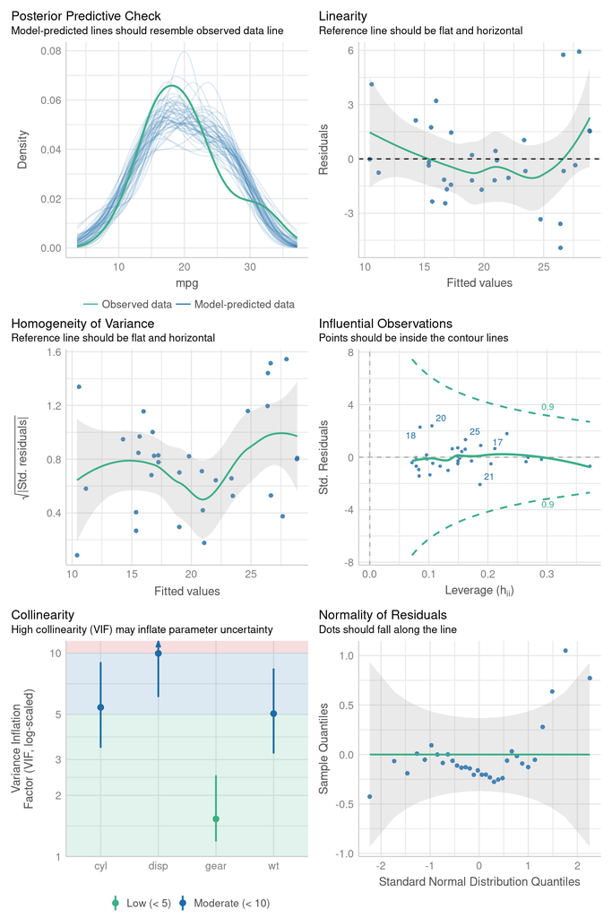

```r
m <- lm(mpg ~ wt + cyl + gear + disp, data = mtcars)
check_model(m, panel = TRUE) ## default
```

The help for `check_model()` says

> `panel`: Logical, if ‘TRUE’, plots are arranged as panels; else, single plots for each diagnostic are returned.

However, it doesn’t way the expect I would have expected (I’d have thought that it would return a list of plots; instead, it seems to return *data* that could be used to draw plots rather than the plots themselves … *if* you get plots, you can print them one by one or use functions from the `gridExtra`, `cowplot`, or `patchwork` packages to combine them into particular configurations